# Spatial Data Analysis (450:320)

Class 3

The code behind the title page map:

```r
lapply(c("sf", "terra", "ggplot2", "rasterVis", "gstat"),
       library, character.only = TRUE)

# 1. Create a 50 * 50 template SpatRaster
xy_rast <- rast(
    ncols = 50, nrows = 50, xmin = 0.5, xmax = 50.5, ymin = 0.5, ymax = 50.5)

# 2. Define the gstat object and interpolate to the raster
set.seed(2)
gdummy <- gstat(
    formula = z ~ 1, locations = ~x + y, dummy = TRUE, beta = 1,
    model = vgm(psill = 0.35, range = 30, model = 'Sph'), nmax = 20)
r <- interpolate(xy_rast, gdummy, nsim = 1)

# Plot
levelplot(
    r, scales = list(draw = FALSE), axes = FALSE,
    colorkey = list(axis.line = list(col = "#FAF0E6"),
                    axis.text = list(col = "#FAF0E6")))
```

## Class overview

- Fundamentals of `R` (data types and objects, and basic operations)
- `R` packages
- More on Git/GitHub
- Overview of assignment
- Trouble shooting

## A few coding tips

- Use `<-` for assignment and `=` for passing arguments to functions.
  - This is the standard convention in R, and I expect you to follow it.
  - You may encounter R code that uses `=` for assignment. That is acceptable to read and understand.
- Shortcut for `<-`
  - MacOS: `option` + `-`
  - Windows: `Alt` + `-`

## A few coding tips

- In R Markdown, shortcut to insert an R code chunk
  - Windows: `Ctrl` + `Alt` + `I`
  - MacOS: `option` + `command` + `I`
- Shortcut to run selected lines
  - Windows: `Ctrl` + `Enter`
  - MacOS: `command` + `Enter`
- Help
  - `?function`
  - `??function`

## Fundamentals of R

Q: Why do we need to learn the fundamentals of R for working with spatial data? Hint:

- What are the two main data types in GIS?
- What do they look like?

## Fundamentals of R

### Data types

There are 6 atomic data types (or we could say classes of objects):

- character, e.g. `'hello world'`, `'abc'`
- double (real or decimal), e.g. `10`, `3.14`, `1e10`
- integer, e.g. `1L`
- logical, e.g. `TRUE`, `FALSE`, `T`, `F`
- complex, e.g. `1 + 3i` (not commonly used by us)
- *raw* (rarely used by us)

## Fundamentals of R

### Other special data types

- `NULL`: means not exist
- Missing data: `NA`. It is a special logical type, but can be convert to the specific type automatically when it is used with other data types.
- Infinity: `Inf` (e.g. `1 / 0`) and `-Inf` (e.g. `-1 / 0`. They are special double type.
- Undefined value: `NaN`. It is also a special double type. (e.g. `0 / 0`)

## Fundamentals of R

### Other special data types

- Date: `as.Date('1970-1-5')`
- Time: `as.POSIXct('1970-1-5')`
- Factor: factor could be treated as integers with labels for categorical data. Function `levels(f)` can get these labels.

## Fundamentals of R

### Data type checking

- `typeof(x)`
- `is.xxx(x)`:
  - e.g. `is.double(x)`, `is.integer(x)`, `is.logical(x)`, `is.character(x)`, `is.complex(x)`, `is.raw(x)`, `is.factor`
  - `is.numeric(x)` exams that objects behave like numbers.
  - e.g. `is.na(y)`, `is.nan(y)`, `is.null(y)`, `is.infinite(y)`, `is.finite(y)`.

## Fundamentals of R

### Data type converting

- `as.xxx(x)`:
  - e.g. `as.numeric(x)`, `as.double(x)`, `as.character(x)`, `as.integer(x)`, `as.logical(x)`, `as.complex(x)`, `as.raw(x)`, `as.factor(x)`, `as.Date(x)`, `as.POSIXct(x)`.
- logical < integer < double < character

## Fundamentals of R

### Vectors

- Atomic vectors (usually refer to vector):
  - A vector is a sequence of objects of the **same class**.
  - Arrays and matrices are special type of vectors with dimensions.
    - Matrices have 2 dimensions.
    - Arrays could have higher dimensions.

## Fundamentals of R

### Vectors

- Lists
  - Superficially for users, a list can contain objects of **different classes**.
  - Like vectors, a list can also be converted to list-matrix or list-array by defining dimensions.
  - `data.frame` and `tibble` are two S3 object-oriented objects that are created upon `list` for tabular data.

## Fundamentals of R

### Vectors

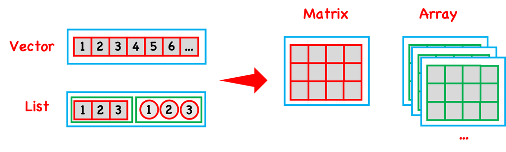

## Fundamentals of R

### Creation

- Function `vector(mode, length)` can be used to initialize a vector of specific data type with defined length.
- More commonly, function `c` (short for concatenate) can be used to create vectors.
- `cbind` and `rbind` are functions can bind `vector`s to a `matrix`. Function `matrix(data_vector, nrow, ncol)` also can be used to create a matrix, and `array(data_vector, dim)` for array.
- Anything can feed in function `list` to create a list, the same as `data.frame`.
- `is.xxx(x)` and `as.xxx(x)` also works for vector, matrix, array, list, and data.frame.

## Fundamentals of R

### Atrributes

Any objects have attributes. If nothing is set, the attributes of an object is `NULL`. Some common attributes include:

- `names`/`dimnames`/`rownames`/`colnames`
- Overall `length`, and more specifically `dim` for matrix and array. Resetting `dim` attribute can convert a vector to matrix/array or reconstruct a matrix/array.

## Practice

Create a `data.frame` with exactly **20 rows** and **3 columns** that satisfies all the conditions below. And **BE CREATIVE!**

- The first column must be named “number” and contain numeric values of your choice. This column must include exactly one `NA`, one `Inf`, and one `-Inf`.
- The second column must be named “letter” and contain lowercase letters (such as a, b, c, …). This column must include one `NaN` value.
- The third column must be named “logical” and contain only logical values (TRUE or FALSE).

The printing results should be similar to this:

```
   number letter logical
15     15      o    TRUE
16     16      p   FALSE
17     17      q    TRUE
18     NA      r   FALSE
19    Inf      s    TRUE
20   -Inf    NaN   FALSE
```

- I’ll leave you with a short **homework** to review what we’ve learned.
- Now, let’s get back to your package.

## Installing and using packages

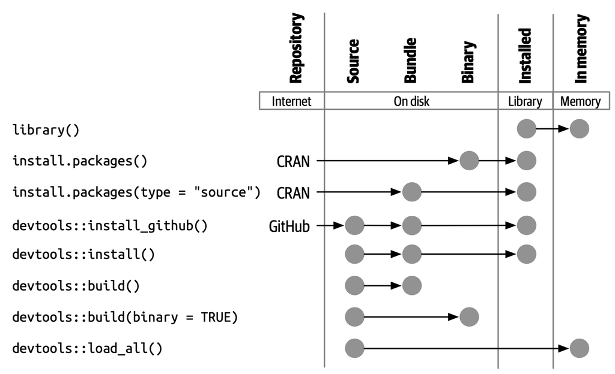

http://r-pkgs.had.co.nz/package.html

## Package structure

General common parts of a package.

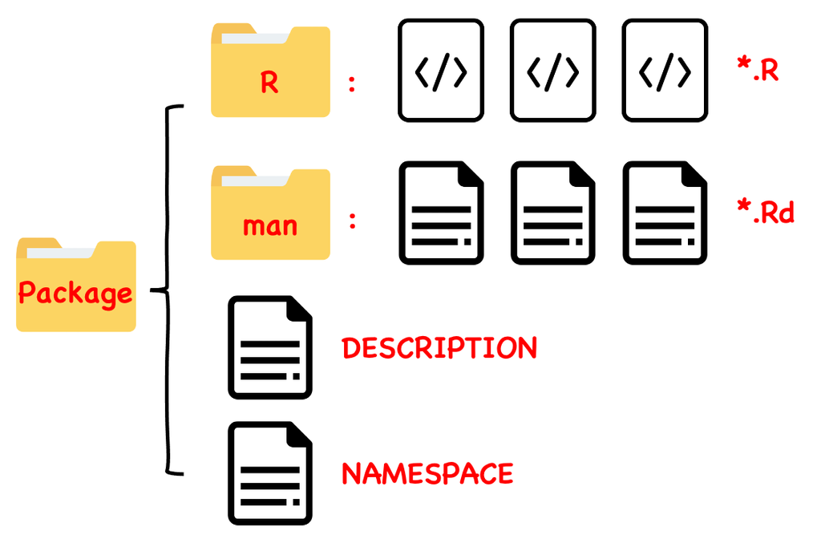

## Package structure

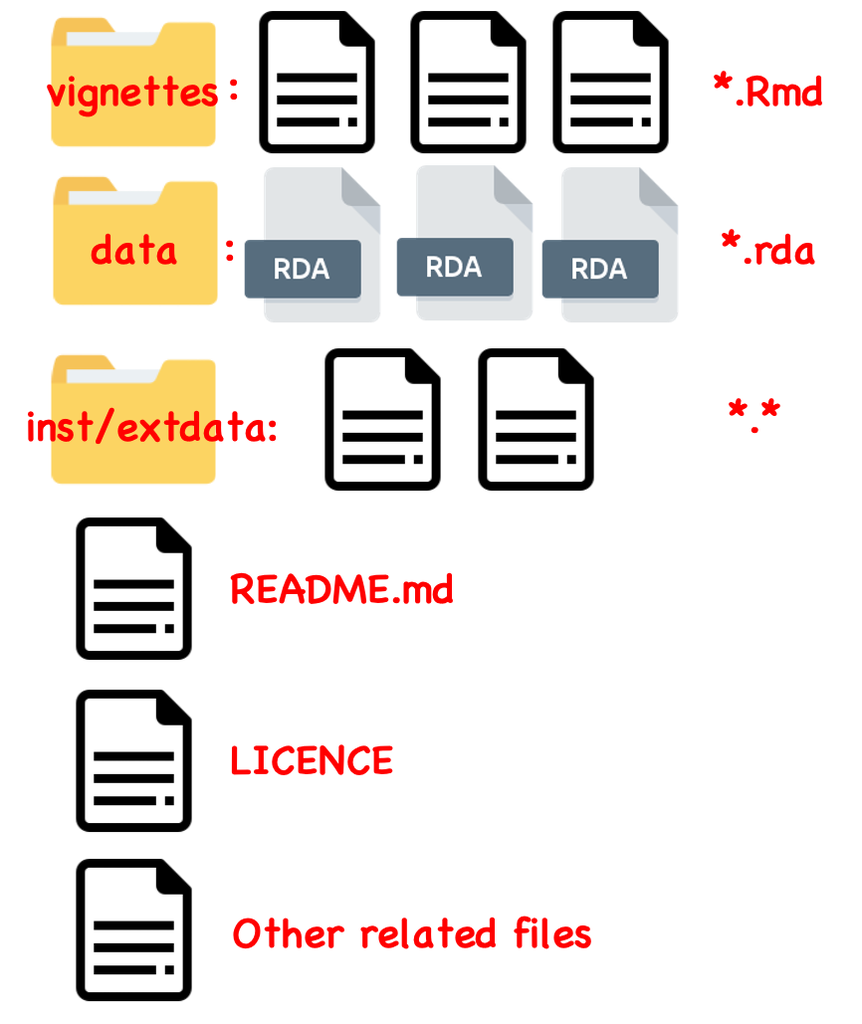

## Package structure

You main tasks for the assignment package are update:

- DESCIPTION file to incorporate updated info (e.g. your package version)
- `.R` files in the **R/** folder (e.g. write functions)
- `.Rmd` files in the **vignettes/** folder (main files for assignments)

## Add a function to your package

- Why we need functions and packages?
  - Reuse -> Reproducibility
- Add a `my_number_checker` function to your package (let me show you first)
- Add a vignette to introduce the function
  - Use `usethis::use_vignette("vignette_name")`
- Update and install the package locally.
- Git add and commit **all** updates.

## Git branching

- Create a new branch named `test` and push to the remote repo
  - `git branch test` (create a new branch)
  - `git checkout test` (switch to the new branch)
  - `git push origin test` (push the new branch to GitHub)
- Have a look your remote repo on GitHub
- Install your package from GitHub
  - In R Console, run

  ```
  devtools::install_github("your repo", build_vignettes = TRUE,
                       auth_token = "paste_your_github_token_here")
  ```

## Our Branching Model for assignments

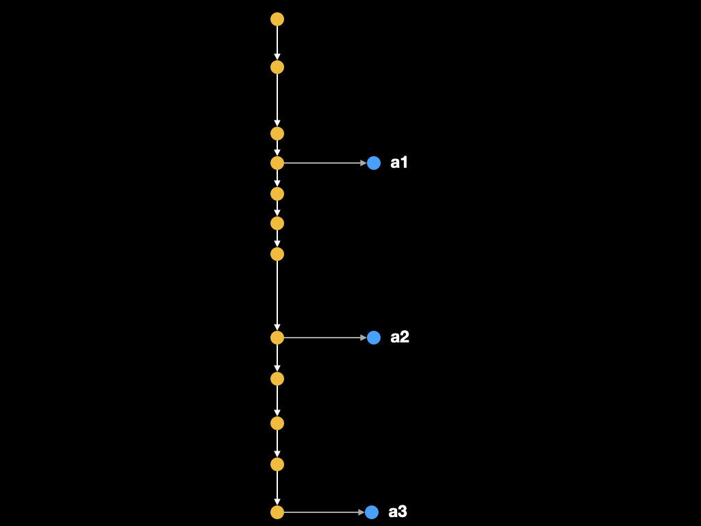

## Delete a branch

- Delete the branch `test` locally and remotely
  - `git checkout main` (park to another branch)
  - `git branch -d test` (delete locally)
  - `git push origin --delete test` (delete remotely)

## Homework

- Write an R markdown that summarizes what we learned about the fundamentals of R.
  - Ideally in your class note folder for your own records
  - The knitted html should look like this: [Expected output](https://sselp.github.io/sdawr//class3_overview_rmarkdown.html).
- Post your **html** file in our Google Chat.
  - This counts for your **participation**.
- Read the rest of Unit1-Module1 and Unit1-Module 2 (we have already covered most of the material).
- **Assignment 1 is due this Friday!**
  - It is at the end of Unit1-Module1
  - Don’t worry! After today’s class, it’ll be an easy task.